# Coding Best Practices Lab – RMarkdown

2023-08-22

## WELCOME

WELCOME TO THE CODING BEST PRACTICES R MARKDOWN LAB. This markdown document will take you through the basics of using markdown to create reproducible and editable reports. The specific goal of the task is to create a report that is easily editable such that someone else using it could change variable names, etc. and see different statistics in the same format.

## Markdown

Rmarkdown uses the document rendering language [Markdown](https://www.markdownguide.org/) to power its text portions. You can do all sorts of fancy things, but some basics include:

- Bulleted lists (like so)
- **Bold** text
- *Italic* text

#### Subheadings and tables of content

And much, much more!

## Coding

But we’re very interested in Rmarkdown because it allows us to embed code, and importantly the code’s output, in our document. In order to add a code chunk, you use three “`” and then tell markdown what language to interpret (in RMarkdown it’s almost always… R). Here’s an example, where we load a package and the data we’ll be using, and summarize one of the variables (days worked in the past week):

```r
library(haven)
library(dplyr)
setwd('~/Documents/CBP_Lab')
base <- read_stata('Data/baseline.dta')
summary(base$s2_4_work_days_num)
```

```
##    Min. 1st Qu.  Median    Mean 3rd Qu.    Max.    NA's
##   1.000   3.000   4.000   4.275   6.000   7.000    1126
```

## Task

We’ll be using a baseline dataset for a study of elderly individuals in Tamil Nadu. The PIs want to prepare for periodically being asked by their government partners for updates and summary statistics from the data. Each government official will have indicators that they personally think are the most important, but the PIs have noticed that the presentation tends to go well when they have a few pieces of information:

- Basic indicators of prevalence of the indicator in the population
- Summary stats of the indicator by gender
- Correlation of the indicator with another indicator.

Therefore the PIs have tasked you with creating a report template that they can use to quickly adapt these reports to the specific variables that individual partners are interested in. How exactly you want to do this is up to you, but a basic structure would be three code chunks and three documentation pieces, one each for the three bullets above. The code below sets up that very basic structure and provides some useful hints/tips, but feel free to change it based on your vision!

### Basic prevalence

```r
prev <- summary(base$s2_4_work_days_num)
prev
```

```
##    Min. 1st Qu.  Median    Mean 3rd Qu.    Max.    NA's
##   1.000   3.000   4.000   4.275   6.000   7.000    1126
```

Hint: You can reference variables assigned in code chunks in text as well! Just use “r [VAR]” in `` in your text. Example: The mean days worked is 4.2748538

### Sum stats by group

```r
gend <- base %>%
  group_by(female) %>%
  dplyr::summarise(mean = mean(s2_4_work_days_num,na.rm = TRUE))
gend
```

```
## # A tibble: 2 × 2
##   female  mean
##    <dbl> <dbl>
## 1      0  4.18
## 2      1  4.30
```

Hint: the knitr/kable [packages](https://cran.r-project.org/web/packages/kableExtra/vignettes/awesome_table_in_html.html) in R can help create well-formatted tables!

### Correlation

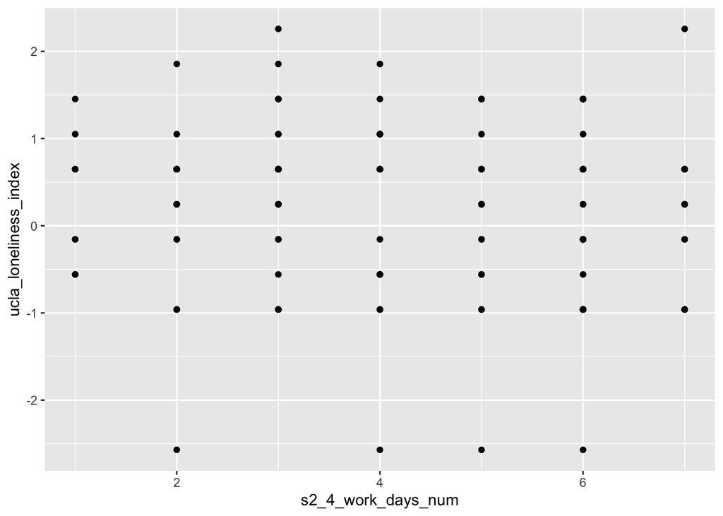

```r
library(ggplot2)
ggplot(data = base) +
  geom_point(mapping = aes(x = s2_4_work_days_num, y = ucla_loneliness_index))
```

Hint: Often scatterplots are good at showing correlation between two variables, and ggplot graphs are incredibly customizable! See more [here](https://ggplot2.tidyverse.org/)